# Final deliverable 02: Air-Quality Exposure Monitoring in R (Programming, SQL and Probability)

Marcos Cunchillos Just

2026-11-24

```r
library(dplyr)
library(ggplot2)
library(DBI)
library(RSQLite)
```

## Overview

An independent mini-project that combines the three core skills of the module on a small environmental-health scenario: **fine particulate matter (PM2.5) monitoring** at five urban sites.

PM2.5 (particles smaller than 2.5 µm) penetrates deep into the lungs and the bloodstream, and it is one of the most studied components of the human *exposome*. Monitoring networks compare daily readings against a reference value; here we use the WHO 24-hour guideline of **15 µg/m³**. A reading **exceeds** the guideline when it is *strictly greater* than 15 µg/m³.

| Part | Topic | Main tools |
| --- | --- | --- |
| 1 | Data audit, control flow | `for`, `while`, `if`/`else` |
| 2 | A validated summary function | functions, input checks, Roxygen2 |
| 3 | SQL queries on the readings | `DBI`, `RSQLite`, `JOIN`, `HAVING` |
| 4 | Probability and simulation | binomial, Poisson, normal, hypergeometric |

> **Data note.** The dataset is **synthetic** and generated reproducibly below (`set.seed`). It mimics real monitoring problems (missing values, sensor errors, borderline readings) but contains no real measurements.

## Data generation

```r
set.seed(2026)

sites <- c("Harbour", "Old Town", "Industrial Park", "Hillside", "Riverside")
median_pm25 <- c(14, 12, 19, 8, 11)          # typical level of each site (ug/m3)
n_per_site <- 24

readings <- data.frame(
  reading_id = sprintf("PM%03d", 1:(length(sites) * n_per_site)),
  site       = rep(sites, each = n_per_site),
  pm25       = round(rlnorm(length(sites) * n_per_site,
                            meanlog = log(rep(median_pm25, each = n_per_site)),
                            sdlog   = 0.45), 1)
)

# Inject typical data-quality problems
readings$pm25[c(5, 31, 58, 90)] <- NA        # missing values (sensor offline)
readings$pm25[c(14, 77)]        <- c(-1.0, -3.2)  # physically impossible (sensor error)
readings$pm25[40]               <- 15        # borderline reading, exactly at the limit
readings$pm25[1:3]              <- c(11.2, 8.6, 13.9)  # first days below the limit

sites_info <- data.frame(
  site      = sites,
  zone_type = c("Port", "Residential", "Industrial", "Residential", "Residential"),
  residents = c(12, 35, 4, 9, 21)            # thousands of residents
)
```

# Part 1. Programming fundamentals

## 1.1 Data audit

> Show the structure of `readings`. Count the missing values and the negative values, and explain why `na.rm = TRUE` is needed for the second count.

```r
str(readings)
```

```
## 'data.frame':    120 obs. of  3 variables:
##  $ reading_id: chr  "PM001" "PM002" "PM003" "PM004" ...
##  $ site      : chr  "Harbour" "Harbour" "Harbour" "Harbour" ...
##  $ pm25      : num  11.2 8.6 13.9 13.5 NA 4.5 10.1 8.8 14.7 11.3 ...
```

```r
n_missing  <- sum(is.na(readings$pm25))
n_negative <- sum(readings$pm25 < 0, na.rm = TRUE)

c(missing = n_missing, negative = n_negative)
```

```
##  missing negative
##        4        2
```

A comparison such as `pm25 < 0` returns `NA` for a missing reading, and `sum()` of a vector that contains `NA` is `NA`. With `na.rm = TRUE` the missing values are skipped, so only real negative readings are counted. The data contain 4 missing and 2 negative readings out of 120.

## 1.2 Classification with a `for` loop

> Build a vector `status` with one label per reading: `"missing"` if the value is `NA`, `"sensor_error"` if it is negative, `"exceedance"` if it is strictly above 15 and `"compliant"` otherwise. Count how many readings fall in each category **inside the same loop**, using a named vector as counter.

```r
limit <- 15
status <- character(nrow(readings))
counts <- c(missing = 0, sensor_error = 0, exceedance = 0, compliant = 0)

for (i in seq_len(nrow(readings))) {
  if (is.na(readings$pm25[i])) {
    status[i] <- "missing"
  } else if (readings$pm25[i] < 0) {
    status[i] <- "sensor_error"
  } else if (readings$pm25[i] > limit) {
    status[i] <- "exceedance"
  } else {
    status[i] <- "compliant"
  }
  counts[status[i]] <- counts[status[i]] + 1
}

counts
```

```
##      missing sensor_error   exceedance    compliant
##            4            2           37           77
```

```r
sum(counts) == nrow(readings)   # every reading belongs to exactly one category
```

```
## [1] TRUE
```

The `is.na()` check must come **first**: any comparison with `NA` returns `NA`, and `if (NA)` stops with an error. The borderline reading of exactly 15 µg/m³ is classified as `compliant`, because the exceedance rule is strictly `> 15`.

## 1.3 First exceedance with a `while` loop

> Use a `while` loop to find the position of the first exceedance and report how many readings were processed before it.

```r
i <- 1
while (i <= nrow(readings) && status[i] != "exceedance") {
  i <- i + 1
}

if (i <= nrow(readings)) {
  cat("First exceedance:", readings$reading_id[i],
      "at", readings$site[i], "with", readings$pm25[i], "ug/m3\n")
  cat("Readings processed before it:", i - 1, "\n")
} else {
  cat("No exceedance found\n")
}
```

```
## First exceedance: PM016 at Harbour with 25.7 ug/m3
## Readings processed before it: 15
```

The condition `i <= nrow(readings)` is written **first** so that, when no exceedance exists, the loop stops at the end of the data instead of indexing beyond the last row. Unlike a `for` loop, a `while` loop needs the counter to be initialised and updated by hand; forgetting `i <- i + 1` would loop forever.

# Part 2. A validated summary function

## 2.1 Definition

> Write `exposure_summary(x, limit = 15)`. It receives a vector of PM2.5 readings and returns a list with the number of readings, the mean, the median, the 95th percentile and the percentage of readings strictly above `limit`. It must return an informative text message if `x` is not a non-empty numeric vector without missing or negative values, or if `limit` is not a single positive number.

```r
#' Summarise PM2.5 exposure readings
#'
#' @param x Numeric vector of PM2.5 readings (ug/m3). It must be non-empty and
#'   contain no missing or negative values.
#' @param limit Single positive number used as the exceedance threshold.
#'   Defaults to the WHO 24-hour guideline (15 ug/m3).
#'
#' @return A list with `n_readings`, `mean`, `median`, `p95` and
#'   `percent_above` (percentage of readings strictly above `limit`).
#'   If an input check fails, a character message is returned instead.
exposure_summary <- function(x, limit = 15) {
  # Check the readings
  if (!is.numeric(x) || length(x) == 0) {
    return("Invalid input: x must be a non-empty numeric vector")
  }
  if (anyNA(x) || any(x < 0)) {
    return("Invalid input: x cannot contain missing or negative values")
  }

  # Check the limit (type and length first, sign last)
  if (!is.numeric(limit) || length(limit) != 1 || is.na(limit) || limit <= 0) {
    return("Invalid input: limit must be a single positive number")
  }

  list(
    n_readings    = length(x),
    mean          = mean(x),
    median        = median(x),
    p95           = unname(quantile(x, probs = 0.95)),
    percent_above = sum(x > limit) * 100 / length(x)
  )
}
```

## 2.2 Applying and testing it

> Apply the function to the valid readings of each site and test the edge cases.

```r
valid_readings <- readings %>%
  filter(!is.na(pm25), pm25 >= 0)

# One summary per site
by_site <- t(sapply(split(valid_readings$pm25, valid_readings$site),
                    function(x) unlist(exposure_summary(x))))
round(by_site, 2)
```

```
##                 n_readings  mean median   p95 percent_above
## Harbour                 22 12.90  11.90 25.37         22.73
## Hillside                22  8.59   7.45 15.46          9.09
## Industrial Park         23 17.51  17.30 26.88         65.22
## Old Town                23 15.15  13.90 26.10         43.48
## Riverside               24 11.30   9.10 21.04         20.83
```

```r
exposure_summary(c(0, 15, 20))               # 15 is not an exceedance
```

```
## $n_readings
## [1] 3
##
## $mean
## [1] 11.66667
##
## $median
## [1] 15
##
## $p95
## [1] 19.5
##
## $percent_above
## [1] 33.33333
```

```r
exposure_summary(c(0, 15, 20), limit = 20)
```

```
## $n_readings
## [1] 3
##
## $mean
## [1] 11.66667
##
## $median
## [1] 15
##
## $p95
## [1] 19.5
##
## $percent_above
## [1] 0
```

```r
exposure_summary(c("a", "b"))                # text
```

```
## [1] "Invalid input: x must be a non-empty numeric vector"
```

```r
exposure_summary(numeric(0))                 # empty vector
```

```
## [1] "Invalid input: x must be a non-empty numeric vector"
```

```r
exposure_summary(c(5, -2, 8))                # negative value
```

```
## [1] "Invalid input: x cannot contain missing or negative values"
```

```r
exposure_summary(c(5, NA, 8))                # missing value
```

```
## [1] "Invalid input: x cannot contain missing or negative values"
```

```r
exposure_summary(c(5, 8), limit = c(10, 20)) # limit of length 2
```

```
## [1] "Invalid input: limit must be a single positive number"
```

```r
exposure_summary(c(5, 8), limit = -1)        # negative limit
```

```
## [1] "Invalid input: limit must be a single positive number"
```

The percentage uses `length(x)` as the denominator, that is, the number of **valid readings passed to the function**, not the rows of the original table. Here 114 valid readings enter the summaries, compared with 120 rows in `readings`. With `c(0, 15, 20)` and a limit of 15 only the 20 exceeds it (1 of 3, 33.3 %).

# Part 3. SQL queries

All queries use `dbGetQuery()` and run on the **original** data, including the missing and negative readings.

## 3.1 Connection and tables

```r
con <- dbConnect(SQLite(), ":memory:")
dbWriteTable(con, "readings", readings, row.names = FALSE)
dbWriteTable(con, "sites_info", sites_info, row.names = FALSE)

dbListTables(con)
```

```
## [1] "readings"   "sites_info"
```

```r
dbGetQuery(con, "SELECT COUNT(*) AS n_readings FROM readings")
```

```
##   n_readings
## 1        120
```

## 3.2 Exceedances

> List the readings that exceed 15 µg/m³ (`reading_id`, `site`, `pm25`), from the highest to the lowest value; ties are ordered by `reading_id`.

```r
exceedances <- dbGetQuery(con, "
  SELECT reading_id, site, pm25
  FROM readings
  WHERE pm25 > 15
  ORDER BY pm25 DESC, reading_id ASC")

head(exceedances, 10)
```

```
##    reading_id            site pm25
## 1       PM068 Industrial Park 31.9
## 2       PM119       Riverside 30.8
## 3       PM026        Old Town 28.3
## 4       PM049 Industrial Park 27.2
## 5       PM024         Harbour 27.1
## 6       PM027        Old Town 26.1
## 7       PM030        Old Town 26.1
## 8       PM016         Harbour 25.7
## 9       PM071 Industrial Park 24.0
## 10      PM054 Industrial Park 23.3
```

```r
nrow(exceedances)
```

```
## [1] 37
```

## 3.3 Exceedances per site, with a check

> Count the exceedances per site, ordered by count (descending) and name. Check that the counts add up to the rows of 3.2.

```r
exceed_by_site <- dbGetQuery(con, "
  SELECT site, COUNT(*) AS n_exceedances
  FROM readings
  WHERE pm25 > 15
  GROUP BY site
  ORDER BY n_exceedances DESC, site ASC")
exceed_by_site
```

```
##              site n_exceedances
## 1 Industrial Park            15
## 2        Old Town            10
## 3         Harbour             5
## 4       Riverside             5
## 5        Hillside             2
```

```r
sum(exceed_by_site$n_exceedances) == nrow(exceedances)
```

```
## [1] TRUE
```

## 3.4 Exceedance rate with `CASE` and `HAVING`

> For each site, compute the number of valid readings, the mean and the **percentage of valid readings above the limit**. Keep only the sites whose mean is above 12 µg/m³. Valid means non-missing and non-negative.

```r
site_stats <- dbGetQuery(con, "
  SELECT site,
         COUNT(*)                                             AS n_valid,
         ROUND(AVG(pm25), 2)                                  AS mean_pm25,
         ROUND(100.0 * SUM(CASE WHEN pm25 > 15 THEN 1 ELSE 0 END)
               / COUNT(*), 1)                                 AS pct_exceed
  FROM readings
  WHERE pm25 >= 0
  GROUP BY site
  HAVING AVG(pm25) > 12
  ORDER BY pct_exceed DESC")
site_stats
```

```
##              site n_valid mean_pm25 pct_exceed
## 1 Industrial Park      23     17.51       65.2
## 2        Old Town      23     15.15       43.5
## 3         Harbour      22     12.90       22.7
```

`WHERE` filters **rows** before grouping (here, the invalid readings), while `HAVING` filters **groups** after the aggregation (here, the sites by their mean). The `CASE` expression turns each reading into 1 (exceedance) or 0, so its sum is the number of exceedances.

## 3.5 Joining a second table

> Using `sites_info`, count the exceedances by zone type.

```r
exceed_by_zone <- dbGetQuery(con, "
  SELECT s.zone_type, COUNT(*) AS n_exceedances
  FROM readings AS r
  JOIN sites_info AS s ON r.site = s.site
  WHERE r.pm25 > 15
  GROUP BY s.zone_type
  ORDER BY n_exceedances DESC")
exceed_by_zone
```

```
##     zone_type n_exceedances
## 1 Residential            17
## 2  Industrial            15
## 3        Port             5
```

## 3.6 Visualisation and limitation

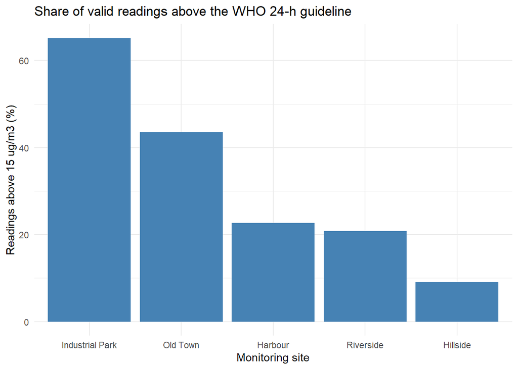

```r
all_sites <- dbGetQuery(con, "
  SELECT site,
         COUNT(*) AS n_valid,
         ROUND(100.0 * SUM(CASE WHEN pm25 > 15 THEN 1 ELSE 0 END)
               / COUNT(*), 1) AS pct_exceed
  FROM readings
  WHERE pm25 >= 0
  GROUP BY site
  ORDER BY pct_exceed DESC")

ggplot(all_sites, aes(x = reorder(site, -pct_exceed), y = pct_exceed)) +
  geom_col(fill = "steelblue") +
  labs(title = "Share of valid readings above the WHO 24-h guideline",
       x = "Monitoring site",
       y = "Readings above 15 ug/m3 (%)") +
  theme_minimal()
```

**Interpretation.** **Industrial Park** has the highest share of exceedances (65.2 % of its 23 valid readings) and **Hillside** the lowest (9.1 %). The ranking follows the typical level assigned to each site when the synthetic data were generated, so with real data the same query would be used to identify the sites that need attention first.

**Limitation.** The percentages are computed on **valid readings only**, and each site loses a different number of readings to missing values and sensor errors. A site can look cleaner simply because its worst days were not recorded, especially if sensors tend to fail during pollution episodes (data that are *not* missing at random). The number of valid readings (`n_valid`) should always be reported next to the percentage.

```r
dbDisconnect(con)
```

# Part 4. Probability and simulation

## 4.1 Binomial model: exceedance days in a month

> At one site, each day exceeds the guideline with probability 0.12, independently of the other days. Over a 30-day month, compute the probability of exactly 5 exceedance days and of 8 or more.

**Model.** Let *X* be the number of exceedance days in 30 days. Then *X* ~ B(30, 0.12), assuming a fixed number of days, two outcomes per day (exceedance or not), independent days and a constant daily probability. (In practice consecutive days are correlated, so this is a simplification.)

```r
n_days <- 30
p_day  <- 0.12

p_exact5   <- dbinom(5, n_days, p_day)
p_atleast8 <- pbinom(7, n_days, p_day, lower.tail = FALSE)  # P(X >= 8) = 1 - P(X <= 7)

c(exactly_5 = p_exact5, at_least_8 = p_atleast8)
```

```
##  exactly_5 at_least_8
## 0.14514637 0.02205018
```

## 4.2 Poisson model: smoke episodes

> Wildfire-smoke episodes affect the area at a constant average rate of 0.8 per month. Compute the probability of no episode in 3 months and of at least 4 episodes in 6 months. Justify the parameter of each interval.

**Model.** Let *N* be the number of episodes in an interval. For a homogeneous Poisson process, *N* ~ Poisson(λ) with λ = rate × duration, assuming a constant rate, independent counts in separate intervals and events occurring one at a time.

- 3 months: λ = 0.8 × 3 = 2.4
- 6 months: λ = 0.8 × 6 = 4.8

```r
lambda_3m <- 0.8 * 3
lambda_6m <- 0.8 * 6

p_none_3m    <- dpois(0, lambda_3m)
p_atleast4_6 <- ppois(3, lambda_6m, lower.tail = FALSE)     # P(N >= 4) = 1 - P(N <= 3)

c(none_in_3_months = p_none_3m, at_least_4_in_6_months = p_atleast4_6)
```

```
##       none_in_3_months at_least_4_in_6_months
##             0.09071795             0.70577008
```

## 4.3 Normal model: a station’s daily mean

> The daily mean PM2.5 at a station is modelled as N(12, 4²) µg/m³ (mean 12, standard deviation 4). Compute the probability of exceeding 15 µg/m³ and the value exceeded only 5 % of the days.

```r
p_exceed_normal <- pnorm(15, mean = 12, sd = 4, lower.tail = FALSE)
q95_normal      <- qnorm(0.95, mean = 12, sd = 4)

c(P_above_15 = p_exceed_normal, percentile_95 = q95_normal)
```

```
##    P_above_15 percentile_95
##     0.2266274    18.5794145
```

For a continuous variable, `P(X > 15) = P(X >= 15)`, so no adjustment of the limit is needed (unlike the discrete cases above).

## 4.4 Simulation versus exact values

> Simulate 10,000 repetitions of each model, estimate the five probabilities above and compare them with the exact values. Plot the theoretical probability functions of the two discrete models.

```r
set.seed(11)
n_rep <- 10000

sim_binom <- rbinom(n_rep, n_days, p_day)
sim_pois3 <- rpois(n_rep, lambda_3m)
sim_pois6 <- rpois(n_rep, lambda_6m)
sim_norm  <- rnorm(n_rep, mean = 12, sd = 4)

comparison <- data.frame(
  event     = c("X = 5", "X >= 8", "N(3 months) = 0", "N(6 months) >= 4", "Mean > 15"),
  exact     = c(p_exact5, p_atleast8, p_none_3m, p_atleast4_6, p_exceed_normal),
  estimated = c(mean(sim_binom == 5), mean(sim_binom >= 8),
                mean(sim_pois3 == 0), mean(sim_pois6 >= 4),
                mean(sim_norm > 15))
)
comparison$difference <- comparison$estimated - comparison$exact
comparison[, -1] <- round(comparison[, -1], 4)
comparison
```

```
##              event  exact estimated difference
## 1            X = 5 0.1451    0.1519     0.0068
## 2           X >= 8 0.0221    0.0237     0.0016
## 3  N(3 months) = 0 0.0907    0.0908     0.0001
## 4 N(6 months) >= 4 0.7058    0.7072     0.0014
## 5        Mean > 15 0.2266    0.2259    -0.0007
```

Each probability is estimated as the **proportion of repetitions** in which the event occurs. The largest absolute difference is 0.0068. The estimates are close to the exact values but not identical because they are random; they change with the seed and converge to the exact values as the number of repetitions grows (law of large numbers).

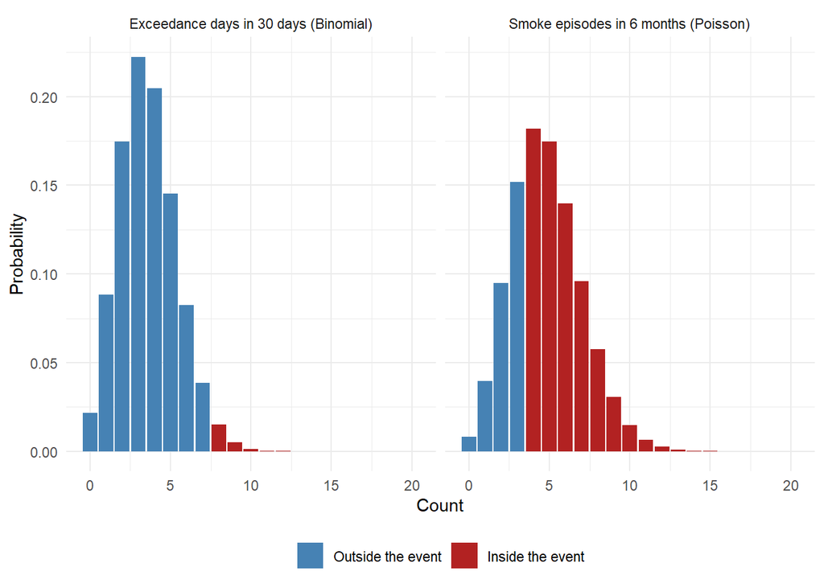

```r
x <- 0:20
pmf <- rbind(
  data.frame(model = "Exceedance days in 30 days (Binomial)",
             count = x, probability = dbinom(x, n_days, p_day),
             in_event = x >= 8),
  data.frame(model = "Smoke episodes in 6 months (Poisson)",
             count = x, probability = dpois(x, lambda_6m),
             in_event = x >= 4)
)

ggplot(pmf, aes(x = count, y = probability, fill = in_event)) +
  geom_col() +
  facet_wrap(~ model) +
  scale_fill_manual(values = c(`FALSE` = "steelblue", `TRUE` = "firebrick"),
                    labels = c("Outside the event", "Inside the event")) +
  labs(x = "Count", y = "Probability", fill = NULL) +
  theme_minimal() +
  theme(legend.position = "bottom")
```

The red bars are the values that make up each event (8 or more exceedance days; at least 4 episodes in six months); the sum of their heights is the probability computed in 4.1 and 4.2.

## 4.5 Sampling without replacement: filter cartridges

> A batch holds 50 filter cartridges, 6 of them defective. An inspector draws 8 cartridges at random. Estimate by simulation the probability of finding at least 2 defective ones, drawing **without** and **with** replacement, and compare with the exact values. Explain why the binomial model is not exact without replacement.

```r
batch <- c(rep(1, 6), rep(0, 44))   # 1 = defective, 0 = good

set.seed(5)
sim_without <- replicate(10000, sum(sample(batch, 8, replace = FALSE)))
sim_with    <- replicate(10000, sum(sample(batch, 8, replace = TRUE)))

exact_binom <- pbinom(1, 8, 6 / 50, lower.tail = FALSE)      # with replacement
exact_hyper <- phyper(1, 6, 44, 8, lower.tail = FALSE)       # without replacement

data.frame(
  case = c("Without replacement (simulation)", "With replacement (simulation)",
           "Hypergeometric (exact)", "Binomial (exact)"),
  probability = round(c(mean(sim_without >= 2), mean(sim_with >= 2),
                        exact_hyper, exact_binom), 4)
)
```

```
##                               case probability
## 1 Without replacement (simulation)      0.2423
## 2    With replacement (simulation)      0.2490
## 3           Hypergeometric (exact)      0.2416
## 4                 Binomial (exact)      0.2480
```

Without replacement, every cartridge drawn leaves the batch, so the composition of what remains changes at each draw: after a defective cartridge is removed, the probability that the next one is defective drops from 6/50 to 5/49. The draws are therefore **not independent** and the probability is **not constant**, which violates both binomial assumptions. The exact model is the **hypergeometric** distribution (0.2416), slightly different from the binomial value (0.248). The binomial becomes a good approximation when the batch is much larger than the sample drawn.